# 07_analysis_t_test

Julie Bruun Brockhoff (s204519), Cecilie Kejlberg Leth (s204584), Amalie Drud Nielsen (s204560), Chrysillis Hellemann Polhaus (s153664), Lise Lotte Eriksen (s154123)

### Load packages

```r
library(tidyverse)
library(broom)
library(here)
library(readr)
```

### Load data

```r
data <- read_tsv(file = here("data/03_dat_aug.tsv"))
```

### Data for analysis

Pivot data to long format

```r
#Data for comparison of the two cell lines
mock_or_ko <- data |>
  select(gene,
         contains("_MOCK"),
         contains("_KO")) |>
  pivot_longer(cols = c(OVCAR3_MOCK,
                        OVCAR3_KO,
                        SKOV3_MOCK,
                        SKOV3_KO),
               names_to = c(".value",
                            "MOCK_or_KO"),
               names_pattern = "(.*)_(.*)")

#Data for comparison of KO and baseline in OVCAR3
OVCAR3_mock_or_ko <- data |>
    filter(DEG_OVCAR3 == "Upregulated" |
           DEG_OVCAR3 == "Downregulated") |>
  select(gene, OVCAR3_MOCK, OVCAR3_KO) |>
  pivot_longer(cols = c(OVCAR3_MOCK,
                        OVCAR3_KO),
               names_to = c(".value",
                            "MOCK_or_KO"),
               names_pattern = "(.*)_(.*)" )

#Data for comparison of KO and baseline in SKOV3
SKOV3_mock_or_ko <- data |>
    filter(DEG_SKOV3 == "Upregulated" |
           DEG_SKOV3 == "Downregulated") |>
  select(gene, SKOV3_MOCK, SKOV3_KO) |>
  pivot_longer(cols = c(SKOV3_MOCK,
                        SKOV3_KO),
               names_to = c(".value",
                            "MOCK_or_KO"),
               names_pattern = "(.*)_(.*)" )
```

### Regression models for KO and baseline in the two cell lines

Fitting linear models of how the two cell lines correlate for both KO and MOCK

```r
#Regression model for KO genes
model_KO <- mock_or_ko |>
  filter(MOCK_or_KO == "KO") |>
  lm(formula = SKOV3 ~ OVCAR3)

summary(model_KO)
```

```
##
## Call:
## lm(formula = SKOV3 ~ OVCAR3, data = filter(mock_or_ko, MOCK_or_KO ==
##     "KO"))
##
## Residuals:
##    Min     1Q Median     3Q    Max
## -65304   -373   -369   -124  58151
##
## Coefficients:
##              Estimate Std. Error t value Pr(>|t|)
## (Intercept) 3.723e+02  9.869e+00   37.72   <2e-16 ***
## OVCAR3      2.946e-01  1.322e-03  222.89   <2e-16 ***
## ---
## Signif. codes:  0 '***' 0.001 '**' 0.01 '*' 0.05 '.' 0.1 ' ' 1
##
## Residual standard error: 1648 on 28038 degrees of freedom
## Multiple R-squared:  0.6392, Adjusted R-squared:  0.6392
## F-statistic: 4.968e+04 on 1 and 28038 DF,  p-value: < 2.2e-16
```

```r
#Regression model for baseline genes
model_MOCK <- mock_or_ko |>
  filter(MOCK_or_KO == "MOCK") |>
  lm(formula = SKOV3 ~ OVCAR3)

summary(model_MOCK)
```

```
##
## Call:
## lm(formula = SKOV3 ~ OVCAR3, data = filter(mock_or_ko, MOCK_or_KO ==
##     "MOCK"))
##
## Residuals:
##    Min     1Q Median     3Q    Max
## -68239    -86    -83    -64  61756
##
## Coefficients:
##              Estimate Std. Error t value Pr(>|t|)
## (Intercept) 83.475451   8.355931    9.99   <2e-16 ***
## OVCAR3       1.209690   0.002595  466.08   <2e-16 ***
## ---
## Signif. codes:  0 '***' 0.001 '**' 0.01 '*' 0.05 '.' 0.1 ' ' 1
##
## Residual standard error: 1376 on 28038 degrees of freedom
## Multiple R-squared:  0.8857, Adjusted R-squared:  0.8857
## F-statistic: 2.172e+05 on 1 and 28038 DF,  p-value: < 2.2e-16
```

### Scatter plot between KO and baseline

Scatter plot showing the difference between KO and baseline including the values from the linear models

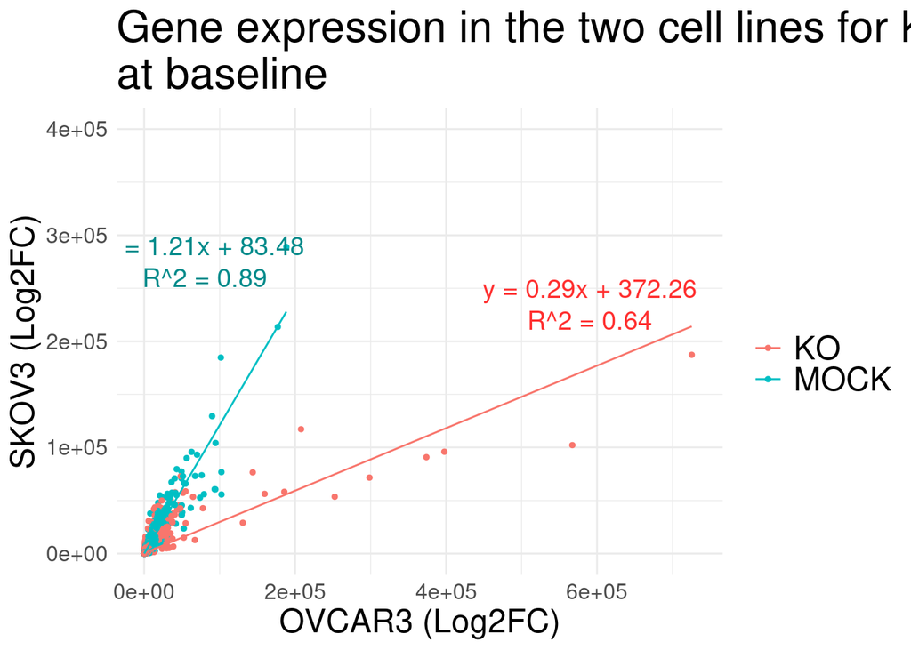

```r
scatterplot_mock_ko <- mock_or_ko |>
  ggplot(mapping = aes(x = OVCAR3,
                       y = SKOV3,
                       color = MOCK_or_KO)) +
  geom_point(size = 1) +
  geom_smooth(method = lm,
              linewidth = 0.5,
              se = FALSE) +
  labs(title = "Gene expression in the two cell lines for KO and \nat baseline",
       x = "OVCAR3 (Log2FC)",
       y = "SKOV3 (Log2FC)",
       color = "") +
  theme_minimal() +
  theme(plot.title = element_text(size = 24),
        axis.title = element_text(size = 18),
        axis.text = element_text(size = 12),
        legend.title = element_text(size = 20),
        legend.text = element_text(size = 18)) +
  scale_x_continuous(limits = c(0,730000)) +
  scale_y_continuous(limits = c(0,400000)) +
  annotate("text",
           x = 590000, y = 220000,
           size = 5,
           label = "R^2 = 0.64",
           color = "firebrick1") +
  annotate("text",
           x = 590000, y = 250000,
           size = 5,
           label = "y = 0.29x + 372.26",
           color = "firebrick1") +
  annotate("text",
           x = 80000, y = 260000,
           size = 5,
           label = "R^2 = 0.89",
           color = "cyan4") +
  annotate("text",
           x = 80000, y = 290000,
           size = 5,
           label = "y = 1.21x + 83.48",
           color = "cyan4")

scatterplot_mock_ko
```

There is a positive correlation between the two cell lines for both the knock-out and the baseline. The genes for the baseline (MOCK) cell lines correlate the best. This indicates that the two cell lines are quite similar in the wildtype state. However, the two cell lines differ a bit more when we look at the KO cell lines.

Save the plot as png-file in results folder

```r
ggsave(filename = here("results/07_scatter_MOCK_KO.png"),
       plot = scatterplot_mock_ko,
       width = 10,
       height = 6)
```

### Statistics: t-test and p-values

Using a t-test to check whether or not the KO and baseline samples are different for each cell line.

```r
KO_OVCAR3 <- OVCAR3_mock_or_ko |>
  filter(MOCK_or_KO == "KO") |>
  select(OVCAR3)

MOCK_OVCAR3 <- OVCAR3_mock_or_ko |>
  filter(MOCK_or_KO == "MOCK") |>
  select(OVCAR3)

#t-test for OVCAR3
broom::tidy(t.test(KO_OVCAR3, MOCK_OVCAR3), paired = TRUE)|>
  pull(p.value)
```

```
## [1] 0.7957103
```

```r
KO_SKOV3 <- SKOV3_mock_or_ko |>
  filter(MOCK_or_KO == "KO") |>
  select(SKOV3)

MOCK_SKOV3 <- SKOV3_mock_or_ko |>
  filter(MOCK_or_KO == "MOCK") |>
  select(SKOV3)

#t-test for SKOV3
broom::tidy(t.test(KO_SKOV3, MOCK_SKOV3), paired = TRUE)|>
  pull(p.value)
```

```
## [1] 0.06881636
```

The p-value is 0.79 for OVCAR3. This means that there are no statistical significant difference between the values of KO vs baseline (MOCK) in this cell line.

The p-value is 0.0688 for SKOV3. This means that there are no statistical significant difference between the values of KO vs baseline (MOCK) in this cell line.

### Significant difference between KO and baseline in the cell lines for GDF15 gene

The GDF15 gene has been shown to be highly induced in ovarian cell cancer, this gene is investigated for our cell lines and their KO’s.

```r
gdf15 <- data |>
  filter(gene == "GDF15") |>
  select(OVCAR3_MOCK, OVCAR3_KO, SKOV3_MOCK, SKOV3_KO) |>
  pivot_longer(cols = c(OVCAR3_MOCK,
                        OVCAR3_KO,
                        SKOV3_MOCK,
                        SKOV3_KO),
               names_to = c(".value",
                            "MOCK_or_KO"),
               names_pattern = "(.*)_(.*)")

gdf15_matrix <- gdf15 |>
  column_to_rownames(var = "MOCK_or_KO") |>
  as.matrix()
```

### Fishers test

```r
fisher.test(gdf15_matrix)
```

```
##
##  Fisher's Exact Test for Count Data
##
## data:  gdf15_matrix
## p-value < 2.2e-16
## alternative hypothesis: true odds ratio is not equal to 1
## 95 percent confidence interval:
##  15.90927 18.05298
## sample estimates:
## odds ratio
##   16.93618
```

The fisher test for the GDF15 gene between each of the conditions (KO, MOCK and cell line) shows a p-value of 2.2*10^-16. Which means that there is a strong significant difference between the conditions for this gene.